# `Anova` Anova Tables for Various Statistical Models

Anova Anova Tables for Various Statistical Models

#### Description

Calculates type-II or type-III analysis-of-variance tables for model objects produced by lm, glm, multinom (in the nnet package), polr (in the MASS package), coxph (in the survival package), coxme (in the coxme pckage), svyglm (in the survey package), rlm (in the MASS package), lmer in the lme4 package, lme in the nlme package, and (by the default method) for most models with a linear predictor and asymptotically normal coefficients (see details below). For linear models, 4 Anova F-tests are calculated; for generalized linear models, likelihood-ratio chisquare, Wald chisquare, or F-tests are calculated; for multinomial logit and proportional-odds logit models, likelihood-ratio tests are calculated. Various test statistics are provided for multivariate linear models produced by lm or manova. Partial-likelihood-ratio tests or Wald tests are provided for Cox models. Wald chi-square tests are provided for fixed effects in linear and generalized linear mixed-effects models. Wald chi-square or F tests are provided in the default case.

#### Usage

```
Anova(mod, ...)
Manova(mod, ...)
## S3 method for class 'lm'
Anova(mod, error, type=c("II","III", 2, 3),
white.adjust=c(FALSE, TRUE, "hc3", "hc0", "hc1", "hc2", "hc4"),
vcov.=NULL, singular.ok, ...)
## S3 method for class 'aov'
Anova(mod, ...)
## S3 method for class 'glm'
Anova(mod, type=c("II","III", 2, 3),
test.statistic=c("LR", "Wald", "F"),
error, error.estimate=c("pearson", "dispersion", "deviance"),
singular.ok, ...)
## S3 method for class 'multinom'
Anova(mod, type = c("II","III", 2, 3), ...)
## S3 method for class 'polr'
Anova(mod, type = c("II","III", 2, 3), ...)
## S3 method for class 'mlm'
Anova(mod, type=c("II","III", 2, 3), SSPE, error.df,
idata, idesign, icontrasts=c("contr.sum", "contr.poly"), imatrix,
test.statistic=c("Pillai", "Wilks", "Hotelling-Lawley", "Roy"),...)
## S3 method for class 'manova'
Anova(mod, ...)
## S3 method for class 'mlm'
Manova(mod, ...)
## S3 method for class 'Anova.mlm'
print(x, ...)
## S3 method for class 'Anova.mlm'
summary(object, test.statistic, univariate=object$repeated,
Anova 5
multivariate=TRUE, p.adjust.method, ...)
## S3 method for class 'summary.Anova.mlm'
print(x, digits = getOption("digits"),
SSP=TRUE, SSPE=SSP, ... )
## S3 method for class 'univaov'
print(x, digits = max(getOption("digits") - 2L, 3L),
style=c("wide", "long"),
by=c("response", "term"),
...)
## S3 method for class 'univaov'
```

[output cut: 9 more lines]

```
vcov.=vcov(mod, complete=FALSE), singular.ok, ...)
## S3 method for class 'mer'
Anova(mod, type=c("II", "III", 2, 3),
test.statistic=c("Chisq", "F"), vcov.=vcov(mod, complete=FALSE), singular.ok, ...)
## S3 method for class 'merMod'
Anova(mod, type=c("II", "III", 2, 3),
test.statistic=c("Chisq", "F"), vcov.=vcov(mod, complete=FALSE), singular.ok, ...)
## S3 method for class 'svyglm'
Anova(mod, ...)
## S3 method for class 'rlm'
Anova(mod, ...)
## Default S3 method:
Anova(mod, type=c("II", "III", 2, 3),
test.statistic=c("Chisq", "F"), vcov.=vcov(mod, complete=FALSE),
singular.ok, ...)
```

#### Arguments

mod lm, aov, glm, multinom, polr mlm, coxph, coxme, lme, mer, merMod, svyglm, 6 Anova rlm, or other suitable model object. error for a linear model, an lm model object from which the error sum of squares and degrees of freedom are to be calculated. For F-tests for a generalized linear model, a glm object from which the dispersion is to be estimated. If not specified, mod is used. type type of test, “II”, “III”, 2, or 3. Roman numerals are equivalent to the corresponding Arabic numerals. singular.ok defaults to TRUE for type-II tests, and FALSE for type-III tests where the tests for models with aliased coefficients will not be straightforwardly interpretable; if FALSE, a model with aliased coefficients produces an error. test.statistic for a generalized linear model, whether to calculate “LR” (likelihood-ratio), “Wald”, or “F” tests; for a Cox or Cox mixed-effects model, whether to calculate “LR” (partial-likelihood ratio) or “Wald” tests; in the default case or for linear mixed models fit by lmer, whether to calculate Wald “Chisq” or Kenward- Roger “F” tests with Satterthwaite degrees of freedom (warning: the KR F-tests can be very time-consuming). For a multivariate linear model, the multivariate test statistic to compute - one of “Pillai”, “Wilks”, “Hotelling-Lawley”, or “Roy”, with “Pillai” as the default. The summary method for Anova.mlm objects permits the specification of more than one multivariate test statistic, and the default is to report all four. error.estimate for F-tests for a generalized linear model, base the dispersion estimate on the Pearson residuals (“pearson”, the default); use the dispersion estimate in the model object (“dispersion”); or base the dispersion estimate on the residual deviance (“deviance”). For binomial or Poisson GLMs, where the dispersion is fixed to 1, setting error.estimate=“dispersion” is changed to “pearson”, with a warning. white.adjust if not FALSE, the default, tests use a heteroscedasticity-corrected coefficient covariance matrix; the various values of the argument specify different corrections. See the documentation for hccm for details. If white.adjust=TRUE then the “hc3” correction is selected. SSPE For Anova for a multivariate linear model, the error sum-of-squares-and-products matrix; if missing, will be computed from the residuals of the model; for the print method for the summary of an Anova of a multivariate linear model, whether or not to print the error SSP matrix (defaults to TRUE). SSP if TRUE (the default), print the sum-of-squares and cross-products matrix for the hypothesis and the response-transformation matrix. error.df The degrees of freedom for error; if missing, will be taken from the model. i* `data` : an optional data frame giving a factor or factors defining the intra-subject model for multivariate repeated-measures data. See details for an explanation of the intra-subject design and for further explanation of the other arguments relating to intra-subject factors. idesign a one-sided model formula using the “data” in idata and specifying the intrasubject design. icontrasts names of contrast-generating functions to be applied by default to factors and ordered factors, respectively, in the within-subject “data”; the contrasts must Anova 7 produce an intra-subject model matrix in which different terms are orthogonal. The default is c(“contr.sum”, “contr.poly”). imatrix as an alternative to specifying idata, idesign, and (optionally) icontrasts, the model matrix for the within-subject design can be given directly in the form of list of named elements. Each element gives the columns of the within-subject model matrix for a term to be tested, and must have as many rows as there are responses; the columns of the within-subject model matrix for different terms must be mutually orthogonal. x, object object of class “Anova.mlm” to print or summarize. multivariate, univariate compute and print multivariate and univariate tests for a repeated-measures ANOVA or multivariate linear model; the default is TRUE for both for repeated measures and TRUE for multivariate for a multivariate linear model. p.adjust.method if given for a multivariate linear model when univariate tests are requested, the univariate tests are corrected for simultaneous inference by term; if specified, should be one of the methods recognized by p.adjust or TRUE, in which case the default (Holm) adjustment is used. digits minimum number of significant digits to print. style for printing univariate tests if requested for a multivariate linear model; one of “wide”, the default, or “long”. by if univariate tests are printed in “long” style, they can be ordered by “response”, the default, or by “term”. row.names, optional not used. * `vcov.`: in the default method, an optional coefficient-covariance matrix or function to compute a covariance matrix, computed by default by applying the generic vcov function to the model object. A similar argument may be supplied to the lm method, and the default (NULL) is to ignore the argument; if both vcov. and white.adjust are supplied to the lm method, the latter is used. … do not use.

#### Examples

```r
## Two-Way Anova
mod <- lm(conformity ~ fcategory*partner.status, data=Moore,
contrasts=list(fcategory=contr.sum, partner.status=contr.sum))
Anova(mod)
```

```
## Anova Table (Type II tests)
##
## Response: conformity
##                          Sum Sq Df F value   Pr(>F)
## fcategory                 11.61  2  0.2770 0.759564
## partner.status           212.21  1 10.1207 0.002874 **
## fcategory:partner.status 175.49  2  4.1846 0.022572 *
## Residuals                817.76 39
## ---
## Signif. codes:  0 '***' 0.001 '**' 0.01 '*' 0.05 '.' 0.1 ' ' 1
```

```r
## One-Way MANOVA
## See ?Pottery for a description of the data set used in this example.
summary(Anova(lm(cbind(Al, Fe, Mg, Ca, Na) ~ Site, data=Pottery)))
```

```
##
## Type II MANOVA Tests:
##
## Sum of squares and products for error:
##            Al          Fe          Mg          Ca         Na
## Al 48.2881429  7.08007143  0.60801429  0.10647143 0.58895714
## Fe  7.0800714 10.95084571  0.52705714 -0.15519429 0.06675857
## Mg  0.6080143  0.52705714 15.42961143  0.43537714 0.02761571
## Ca  0.1064714 -0.15519429  0.43537714  0.05148571 0.01007857
## Na  0.5889571  0.06675857  0.02761571  0.01007857 0.19929286
##
## ------------------------------------------
##
## Term: Site
##
## Sum of squares and products for the hypothesis:
##             Al          Fe          Mg         Ca         Na
## Al  175.610319 -149.295533 -130.809707 -5.8891637 -5.3722648
## Fe -149.295533  134.221616  117.745035  4.8217866  5.3259491
## Mg -130.809707  117.745035  103.350527  4.2091613  4.7105458
## Ca   -5.889164    4.821787    4.209161  0.2047027  0.1547830
## Na   -5.372265    5.325949    4.710546  0.1547830  0.2582456
##
## Multivariate Tests: Site
##                  Df test stat  approx F num Df   den Df     Pr(>F)
## Pillai            3   1.55394   4.29839     15 60.00000 2.4129e-05 ***
## Wilks             3   0.01230  13.08854     15 50.09147 1.8404e-12 ***
## Hotelling-Lawley  3  35.43875  39.37639     15 50.00000 < 2.22e-16 ***
## Roy               3  34.16111 136.64446      5 20.00000 9.4435e-15 ***
## ---
## Signif. codes:  0 '***' 0.001 '**' 0.01 '*' 0.05 '.' 0.1 ' ' 1
```

```r
## MANOVA for a randomized block design (example courtesy of Michael Friendly:
## See ?Soils for description of the data set)
soils.mod <- lm(cbind(pH,N,Dens,P,Ca,Mg,K,Na,Conduc) ~ Block + Contour*Depth,
data=Soils)
Manova(soils.mod)
```

```
##
## Type II MANOVA Tests: Pillai test statistic
##               Df test stat approx F num Df den Df    Pr(>F)
## Block          3    1.6758   3.7965     27     81 1.777e-06 ***
## Contour        2    1.3386   5.8468     18     52 2.730e-07 ***
## Depth          3    1.7951   4.4697     27     81 8.777e-08 ***
## Contour:Depth  6    1.2351   0.8640     54    180    0.7311
## ---
## Signif. codes:  0 '***' 0.001 '**' 0.01 '*' 0.05 '.' 0.1 ' ' 1
```

```r
summary(Anova(soils.mod), univariate=TRUE, multivariate=FALSE,
p.adjust.method=TRUE)
```

```
##
##  Type II Sums of Squares
##               df       pH         N     Dens        P       Ca      Mg
## Block          3  1.23247 0.0038257 0.111250   6591.2  14.6009 13.8776
## Contour        2  0.26066 0.0054845 0.047279  12224.5  25.3941  6.9637
## Depth          3 14.95897 0.1637141 1.589817 224703.5 378.3826 34.8509
## Contour:Depth  6  0.51587 0.0030885 0.088371  10260.6   8.4497  4.5385
## residuals     33  4.24730 0.0358700 0.433050  55810.8  71.4284 27.7522
##                      K       Na   Conduc
## Block         0.323442  15.4013   7.3116
## Contour       0.473288  13.3148  12.8727
## Depth         1.130825 446.6692 674.4830
## Contour:Depth 0.020263   3.0929   5.8732
## residuals     0.409308  29.9400  46.7515
##
##  F-tests
##                  pH     N  Dens     P    Ca   Mg     K     Na Conduc
## Block          3.19  1.76  2.83  0.65  2.25 8.25  8.69   2.83   1.72
## Contour        1.01  1.68  0.60  2.41  5.87 2.76  6.36   4.89   4.54
## Depth         38.74 25.10 40.38 66.43 58.27 6.91 30.39 246.16 158.70
## Contour:Depth  0.67  0.95  3.37  2.02  0.65 1.80  0.82   1.14   0.69
##
##  p-values
##               pH         N          Dens       P          Ca
## Block         0.03622480 0.18784329 0.05368061 0.69011331 0.10102309
## Contour       0.37427327 0.18986452 0.72782049 0.08459444 0.00661088
## Depth         6.4142e-11 5.6100e-11 3.7698e-11 2.6890e-12 2.8152e-13
## Contour:Depth 0.67593329 0.42910155 0.04669490 0.12985165 0.68927638
##               Mg         K          Na         Conduc
## Block         0.00124231 0.00021642 0.02469800 0.18188132
## Contour       0.05764573 0.00016011 0.00637205 0.01807839
## Depth         8.1354e-05 1.2952e-09 < 2.22e-16 < 2.22e-16
## Contour:Depth 0.16658584 0.45056838 0.34871568 0.65840514
##
##  p-values adjusted (by term) for simultaneous inference by holm method
##               pH         N          Dens       P          Ca
## Block         0.2173488  0.5456440  0.2684030  0.6901133  0.4040923
## Contour       0.7485465  0.5695936  0.7485465  0.3383777  0.0509764
## Depth         2.2440e-10 2.2440e-10 1.8849e-10 1.6134e-11 1.9707e-12
## Contour:Depth 1.0000000  1.0000000  0.4202541  1.0000000  1.0000000
##               Mg         K          Na         Conduc
## Block         0.0099385  0.0019478  0.1728860  0.5456440
## Contour       0.2882286  0.0014410  0.0509764  0.1084704
## Depth         8.1354e-05 2.5904e-09 < 2.22e-16 < 2.22e-16
## Contour:Depth 1.0000000  1.0000000  1.0000000  1.0000000
```

```r
## a multivariate linear model for repeated-measures data
## See ?OBrienKaiser for a description of the data set used in this example.
phase <- factor(rep(c("pretest", "posttest", "followup"), c(5, 5, 5)),
levels=c("pretest", "posttest", "followup"))
hour <- ordered(rep(1:5, 3))
idata <- data.frame(phase, hour)
idata
```

```
##       phase hour
## 1   pretest    1
## 2   pretest    2
## 3   pretest    3
## 4   pretest    4
## 5   pretest    5
## 6  posttest    1
## 7  posttest    2
## 8  posttest    3
## 9  posttest    4
## 10 posttest    5
## 11 followup    1
## 12 followup    2
## 13 followup    3
## 14 followup    4
## 15 followup    5
```

```r
mod.ok <- lm(cbind(pre.1, pre.2, pre.3, pre.4, pre.5,
post.1, post.2, post.3, post.4, post.5,
fup.1, fup.2, fup.3, fup.4, fup.5) ~ treatment*gender,
data=OBrienKaiser)
(av.ok <- Anova(mod.ok, idata=idata, idesign=~phase*hour))
```

```
##
## Type II Repeated Measures MANOVA Tests: Pillai test statistic
##                             Df test stat approx F num Df den Df    Pr(>F)
## (Intercept)                  1   0.96954   318.34      1     10 6.532e-09
## treatment                    2   0.48092     4.63      2     10 0.0376868
## gender                       1   0.20356     2.56      1     10 0.1409735
## treatment:gender             2   0.36350     2.86      2     10 0.1044692
## phase                        1   0.85052    25.61      2      9 0.0001930
## treatment:phase              2   0.68518     2.61      4     20 0.0667354
## gender:phase                 1   0.04314     0.20      2      9 0.8199968
## treatment:gender:phase       2   0.31060     0.92      4     20 0.4721498
## hour                         1   0.93468    25.04      4      7 0.0003043
## treatment:hour               2   0.30144     0.35      8     16 0.9295212
## gender:hour                  1   0.29274     0.72      4      7 0.6023742
## treatment:gender:hour        2   0.57022     0.80      8     16 0.6131884
## phase:hour                   1   0.54958     0.46      8      3 0.8324517
## treatment:phase:hour         2   0.66367     0.25     16      8 0.9914415
## gender:phase:hour            1   0.69505     0.85      8      3 0.6202076
## treatment:gender:phase:hour  2   0.79277     0.33     16      8 0.9723693
##
## (Intercept)                 ***
## treatment                   *
## gender
## treatment:gender
## phase                       ***
## treatment:phase             .
## gender:phase
## treatment:gender:phase
## hour                        ***
## treatment:hour
## gender:hour
## treatment:gender:hour
## phase:hour
## treatment:phase:hour
## gender:phase:hour
## treatment:gender:phase:hour
## ---
## Signif. codes:  0 '***' 0.001 '**' 0.01 '*' 0.05 '.' 0.1 ' ' 1
```

```r
summary(av.ok, multivariate=FALSE)
```

```
##
## Univariate Type II Repeated-Measures ANOVA Assuming Sphericity
##
##                             Sum Sq num Df Error SS den Df  F value
## (Intercept)                 7260.0      1  228.056     10 318.3435
## treatment                    211.3      2  228.056     10   4.6323
## gender                        58.3      1  228.056     10   2.5558
## treatment:gender             130.2      2  228.056     10   2.8555
## phase                        167.5      2   80.278     20  20.8651
## treatment:phase               78.7      4   80.278     20   4.8997
## gender:phase                   1.7      2   80.278     20   0.2078
## treatment:gender:phase        10.2      4   80.278     20   0.6366
## hour                         106.3      4   62.500     40  17.0067
## treatment:hour                 1.2      8   62.500     40   0.0929
## gender:hour                    2.6      4   62.500     40   0.4094
## treatment:gender:hour          7.8      8   62.500     40   0.6204
## phase:hour                    11.1      8   96.167     80   1.1525
## treatment:phase:hour           6.3     16   96.167     80   0.3256
## gender:phase:hour              6.6      8   96.167     80   0.6900
## treatment:gender:phase:hour   14.2     16   96.167     80   0.7359
##                                Pr(>F)
## (Intercept)                 6.532e-09 ***
## treatment                    0.037687 *
## gender                       0.140974
## treatment:gender             0.104469
## phase                       1.274e-05 ***
## treatment:phase              0.006426 **
## gender:phase                 0.814130
## treatment:gender:phase       0.642369
## hour                        3.191e-08 ***
## treatment:hour               0.999257
## gender:hour                  0.800772
## treatment:gender:hour        0.755484
## phase:hour                   0.338317
## treatment:phase:hour         0.992814
## gender:phase:hour            0.699124
## treatment:gender:phase:hour  0.749562
## ---
## Signif. codes:  0 '***' 0.001 '**' 0.01 '*' 0.05 '.' 0.1 ' ' 1
##
```

[output cut: 35 more lines]

```
## Signif. codes:  0 '***' 0.001 '**' 0.01 '*' 0.05 '.' 0.1 ' ' 1
##
##                                HF eps   Pr(>F[HF])
## phase                       0.9278594 2.387543e-05
## treatment:phase             0.9278594 8.089765e-03
## gender:phase                0.9278594 7.984495e-01
## treatment:gender:phase      0.9278594 6.319975e-01
## hour                        0.5592802 2.014357e-05
## treatment:hour              0.5592802 9.887716e-01
## gender:hour                 0.5592802 6.911521e-01
## treatment:gender:hour       0.5592802 6.692976e-01
## phase:hour                  0.7330608 3.440460e-01
## treatment:phase:hour        0.7330608 9.804731e-01
## gender:phase:hour           0.7330608 6.552382e-01
## treatment:gender:phase:hour 0.7330608 7.080122e-01
```

```r
## A "doubly multivariate" design with two distinct repeated-measures variables
## (example courtesy of Michael Friendly)
## See ?WeightLoss for a description of the dataset.
imatrix <- matrix(c(
1,0,-1, 1, 0, 0,
1,0, 0,-2, 0, 0,
1,0, 1, 1, 0, 0,
0,1, 0, 0,-1, 1,
0,1, 0, 0, 0,-2,
0,1, 0, 0, 1, 1), 6, 6, byrow=TRUE)
colnames(imatrix) <- c("WL", "SE", "WL.L", "WL.Q", "SE.L", "SE.Q")
rownames(imatrix) <- colnames(WeightLoss)[-1]
(imatrix <- list(measure=imatrix[,1:2], month=imatrix[,3:6]))
```

```
## $measure
##     WL SE
## wl1  1  0
## wl2  1  0
## wl3  1  0
## se1  0  1
## se2  0  1
## se3  0  1
##
## $month
##     WL.L WL.Q SE.L SE.Q
## wl1   -1    1    0    0
## wl2    0   -2    0    0
## wl3    1    1    0    0
## se1    0    0   -1    1
## se2    0    0    0   -2
## se3    0    0    1    1
```

```r
contrasts(WeightLoss$group) <- matrix(c(-2,1,1, 0,-1,1), ncol=2)
(wl.mod<-lm(cbind(wl1, wl2, wl3, se1, se2, se3)~group, data=WeightLoss))
```

```
##
## Call:
## lm(formula = cbind(wl1, wl2, wl3, se1, se2, se3) ~ group, data = WeightLoss)
##
## Coefficients:
##              wl1       wl2       wl3       se1       se2       se3
## (Intercept)   5.34444   4.45000   2.17778  14.92778  13.79444  16.28333
## group1        0.42222   0.55833   0.04722   0.08889  -0.26944   0.60000
## group2        0.43333   1.09167  -0.02500   0.18333  -0.22500   0.71667
```

```r
Anova(wl.mod, imatrix=imatrix, test="Roy")
```

```
##
## Type II Repeated Measures MANOVA Tests: Roy test statistic
##               Df test stat approx F num Df den Df    Pr(>F)
## measure        1    86.203  1293.04      2     30 < 2.2e-16 ***
## group:measure  2     0.356     5.52      2     31  0.008906 **
## month          1     9.407    65.85      4     28 7.807e-14 ***
## group:month    2     1.772    12.84      4     29 3.909e-06 ***
## ---
## Signif. codes:  0 '***' 0.001 '**' 0.01 '*' 0.05 '.' 0.1 ' ' 1
```

```r
## mixed-effects models examples:
## Not run:
library(nlme)
example(lme)
```

```
##
## lme> fm1 <- lme(distance ~ age, data = Orthodont) # random is ~ age
##
## lme> fm2 <- lme(distance ~ age + Sex, data = Orthodont, random = ~ 1)
##
## lme> summary(fm1)
## Linear mixed-effects model fit by REML
##  Data: Orthodont
##        AIC      BIC    logLik
##   454.6367 470.6173 -221.3183
##
## Random effects:
##  Formula: ~age | Subject
##  Structure: General positive-definite
##             StdDev    Corr
## (Intercept) 2.3270339 (Intr)
## age         0.2264276 -0.609
## Residual    1.3100399
##
## Fixed effects: distance ~ age
##                 Value Std.Error DF   t-value p-value
## (Intercept) 16.761111 0.7752461 80 21.620375       0
## age          0.660185 0.0712533 80  9.265334       0
##  Correlation:
##     (Intr)
## age -0.848
##
## Standardized Within-Group Residuals:
##          Min           Q1          Med           Q3          Max
## -3.223106016 -0.493760867  0.007316632  0.472151090  3.916032742
##
## Number of Observations: 108
## Number of Groups: 27
##
## lme> summary(fm2)
## Linear mixed-effects model fit by REML
##  Data: Orthodont
##        AIC      BIC    logLik
##   447.5125 460.7823 -218.7563
##
## Random effects:
##  Formula: ~1 | Subject
##         (Intercept) Residual
## StdDev:    1.807425 1.431592
##
## Fixed effects: distance ~ age + Sex
##                 Value Std.Error DF   t-value p-value
## (Intercept) 17.706713 0.8339225 80 21.233044  0.0000
## age          0.660185 0.0616059 80 10.716263  0.0000
## SexFemale   -2.321023 0.7614168 25 -3.048294  0.0054
##  Correlation:
##           (Intr) age
## age       -0.813
## SexFemale -0.372  0.000
##
## Standardized Within-Group Residuals:
##         Min          Q1         Med          Q3         Max
## -3.74889609 -0.55034466 -0.02516628  0.45341781  3.65746539
##
## Number of Observations: 108
## Number of Groups: 27
```

```r
Anova(fm2)
```

```
## Analysis of Deviance Table (Type II tests)
##
## Response: distance
##        Chisq Df Pr(>Chisq)
## age 114.8383  1  < 2.2e-16 ***
## Sex   9.2921  1   0.002301 **
## ---
## Signif. codes:  0 '***' 0.001 '**' 0.01 '*' 0.05 '.' 0.1 ' ' 1
```

```r
## End(Not run)
## Not run:
library(lme4)
example(glmer)
```

```
##
## glmer> ## generalized linear mixed model
## glmer> library(lattice)
##
## glmer> xyplot(incidence/size ~ period|herd, cbpp, type=c('g','p','l'),
## glmer+        layout=c(3,5), index.cond = function(x,y)max(y))
```

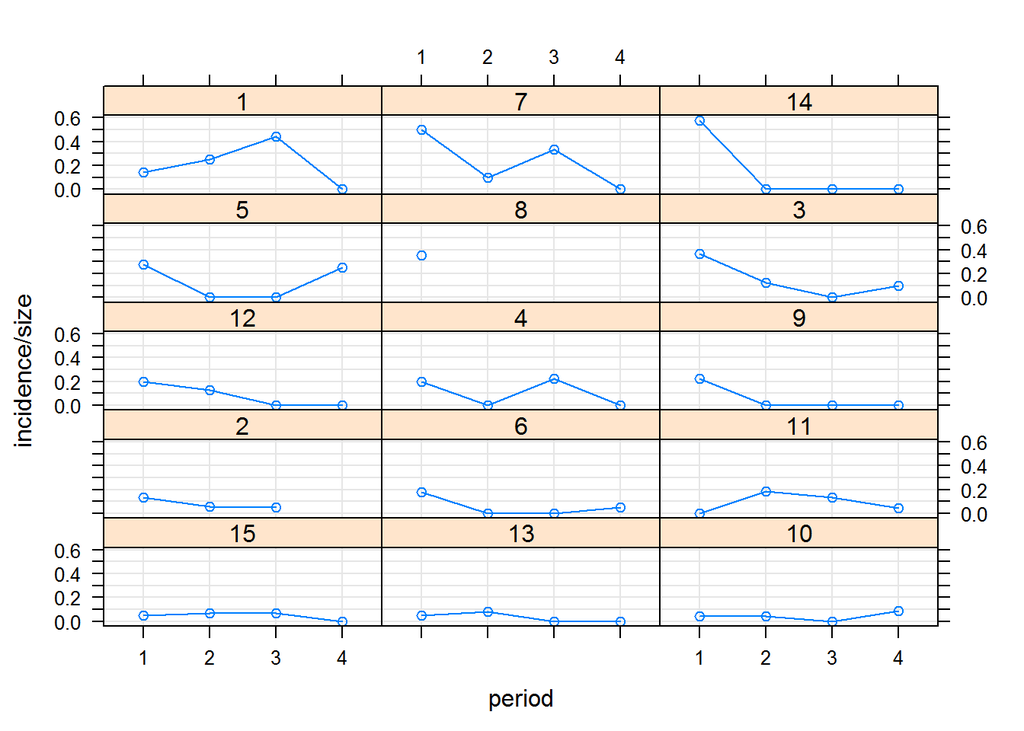

```
##
## glmer> (gm1 <- glmer(cbind(incidence, size - incidence) ~ period + (1 | herd),
## glmer+               data = cbpp, family = binomial))
## Generalized linear mixed model fit by maximum likelihood (Laplace
##   Approximation) [glmerMod]
##  Family: binomial  ( logit )
## Formula: cbind(incidence, size - incidence) ~ period + (1 | herd)
##    Data: cbpp
##      AIC      BIC   logLik deviance df.resid
## 194.0531 204.1799 -92.0266 184.0531       51
## Random effects:
##  Groups Name        Std.Dev.
##  herd   (Intercept) 0.6421
## Number of obs: 56, groups:  herd, 15
## Fixed Effects:
## (Intercept)      period2      period3      period4
##     -1.3983      -0.9919      -1.1282      -1.5797
##
## glmer> ## using nAGQ=0 only gets close to the optimum
## glmer> (gm1a <- glmer(cbind(incidence, size - incidence) ~ period + (1 | herd),
## glmer+                cbpp, binomial, nAGQ = 0))
## Generalized linear mixed model fit by maximum likelihood (Adaptive
##   Gauss-Hermite Quadrature, nAGQ = 0) [glmerMod]
##  Family: binomial  ( logit )
## Formula: cbind(incidence, size - incidence) ~ period + (1 | herd)
##    Data: cbpp
##      AIC      BIC   logLik deviance df.resid
## 194.1087 204.2355 -92.0543 184.1087       51
## Random effects:
##  Groups Name        Std.Dev.
##  herd   (Intercept) 0.6418
## Number of obs: 56, groups:  herd, 15
## Fixed Effects:
## (Intercept)      period2      period3      period4
##     -1.3605      -0.9762      -1.1111      -1.5597
##
## glmer> ## using  nAGQ = 9  provides a better evaluation of the deviance
## glmer> ## Currently the internal calculations use the sum of deviance residuals,
## glmer> ## which is not directly comparable with the nAGQ=0 or nAGQ=1 result.
## glmer> (gm1a <- glmer(cbind(incidence, size - incidence) ~ period + (1 | herd),
```

[output cut: 62 more lines]

```
## glmer> ## compare
## glmer> stopifnot(all.equal(gm1Dev0,c(-2*logLik(gm0))))
##
## glmer> ## the toenail oncholysis data from Backer et al 1998
## glmer> ## these data are notoriously difficult to fit
## glmer> ## Not run:
## glmer> ##D if (require("HSAUR2")) {
## glmer> ##D     gm2 <- glmer(outcome~treatment*visit+(1|patientID),
## glmer> ##D                  data=toenail,
## glmer> ##D                  family=binomial,nAGQ=20)
## glmer> ##D }
## glmer> ## End(Not run)
## glmer>
## glmer>
## glmer>
```

```r
Anova(gm1)
```

```
## Analysis of Deviance Table (Type II Wald chisquare tests)
##
## Response: cbind(incidence, size - incidence)
##         Chisq Df Pr(>Chisq)
## period 25.488  3  1.221e-05 ***
## ---
## Signif. codes:  0 '***' 0.001 '**' 0.01 '*' 0.05 '.' 0.1 ' ' 1
```

```r
## End(Not run)
```

#### Details

The designations “type-II” and “type-III” are borrowed from SAS, but the definitions used here do not correspond precisely to those employed by SAS. Type-II tests are calculated according to the principle of marginality, testing each term after all others, except ignoring the term’s higher-order relatives; so-called type-III tests violate marginality, testing each term in the model after all of the others. This definition of Type-II tests corresponds to the tests produced by SAS for analysis-ofvariance models, where all of the predictors are factors, but not more generally (i.e., when there are quantitative predictors). Be very careful in formulating the model for type-III tests, or the hypotheses tested will not make sense. As implemented here, type-II Wald tests are a generalization of the linear hypotheses used to generate these tests in linear models. For tests for linear models, multivariate linear models, andWald tests for generalized linear models, Cox models, mixed-effects models, generalized linear models fit to survey data, and in the default case, Anova finds the test statistics without refitting the model. The svyglm method simply calls the default method and therefore can take the same arguments. The standard R anova function calculates sequential (“type-I”) tests. These rarely test interesting hypotheses in unbalanced designs. A MANOVA for a multivariate linear model (i.e., an object of class “mlm” or “manova”) can optionally include an intra-subject repeated-measures design. If the intra-subject design is absent (the default), the multivariate tests concern all of the response variables. To specify a repeated-measures design, a data frame is provided defining the repeated-measures factor or factors via idata, with default contrasts given by the icontrasts argument. An intra-subject model-matrix is generated from the formula specified by the idesign argument; columns of the model matrix corresponding to different terms in the intra-subject model must be orthogonal (as is insured by the default contrasts). Note that the contrasts given in icontrasts can be overridden by assigning specific contrasts to the factors in idata. As an alternative, the within-subjects model matrix can be specified directly via the imatrix argument. Manova is essentially a synonym for Anova for multivariate linear models. If univariate tests are requested for the summary of a multivariate linear model, the object returned contains a univaov component of “univaov”; print and as.data.frame methods are provided for the “univaov” class. For the default method to work, the model object must contain a standard terms element, and must respond to the vcov, coef, and model.matrix functions. If any of these requirements is missing, then it may be possible to supply it reasonably simply (e.g., by writing a missing vcov method for the class of the model object).

#### Value

An object of class “anova”, or “Anova.mlm”, which usually is printed. For objects of class “Anova.mlm”, there is also a summary method, which provides much more detail than the print method about theMANOVA, including traditional mixed-model univariate F-tests with Greenhouse- Geisser and Huynh-Feldt corrections. Warning Be careful of type-III tests.

#### #### Author(s)

John Fox jfox@mcmaster.ca; the code for the Mauchly test and Greenhouse-Geisser and Huynh- Feldt corrections for non-spericity in repeated-measures ANOVA are adapted from the functions stats:::stats:::mauchly.test.SSD and stats:::sphericity by R Core; summary.Anova.mlm and print.summary.Anova.mlm incorporates code contributed by Gabriel Baud-Bovy.

#### References

- Fox, J. (2016) Applied Regression Analysis and Generalized Linear Models, Third Edition. Sage.
- Fox, J. and Weisberg, S. (2019) An R Companion to Applied Regression, Third Edition, Sage.
- Hand, D. J., and Taylor, C. C. (1987) Multivariate Analysis of Variance and Repeated Measures: A Practical Approach for Behavioural Scientists. Chapman and Hall.
- O’Brien, R. G., and Kaiser, M. K. (1985) MANOVA method for analyzing repeated measures designs: An extensive primer. Psychological Bulletin 97, 316-333.

Anova 9 See Also linearHypothesis, anova anova.lm, anova.glm, anova.mlm, anova.coxph, svyglm.